# git version control

Florian D. Schneider  
27.08.2014

## Introduction

### why version control?

- traceability of work progress
- **documentation**

### why version control?

- clean working directory
- non-linear development branches
- robust, structured backups
- **progressive development**

### why version control?

- collaborative work
- reviewing
- easy publication
- **openness**

### why version control?

## **Quality management!**

### You allready use version control!

| filename | last updated |
| --- | --- |
| project.c | 01.08.2014 |
| project_v0.1.c | 02.08.2014 |
| project_v0.2.c | 03.08.2014 |
| project_v0.21.c | 04.08.2014 |
| project_v0.2_sonia.c | 04.08.2014 |

### You allready use version control!

| filename | last updated |
| --- | --- |
| project.c | 01.08.2014 |
| project_v0.1.c | 02.08.2014 |
| project_v0.2.c | 03.08.2014 |
| project_v0.21.c | 04.08.2014 |
| project_v0.2_sonia.c | 04.08.2014 |
| project_v0.21_s.c | 05.08.2014 |

### You allready use version control!

| filename | last updated |
| --- | --- |
| project.c | 01.08.2014 |
| project_v0.1.c | 02.08.2014 |
| project_v0.21.c | 04.08.2014 |
| project_v0.2_sonia.c | 04.08.2014 |
| project_v0.21_s.c | 05.08.2014 |
| project_v0.2.c | 07.08.2014 |

### But:

- annoying: there are so many files!
- confusing: which is the latest version?
- not progressive: did you fix that bug in the right file?
- requires manual back-ups

### git

- a version control system
- robust against errors
- platform independent
- geeky command line *or* user-friendly visual software

```
$ git
```

### git

| filename | last updated |
| --- | --- |
| .git | 01.08.2014 |
| project.c | 01.08.2014 |

### git

| filename | last updated |
| --- | --- |
| .git | 02.08.2014 |
| project.c | 02.08.2014 |

### git

| filename | last updated |
| --- | --- |
| .git | 03.08.2014 |
| project.c | 03.08.2014 |

## Basics

### How does it work?

Terminal:

```
$ git init
```

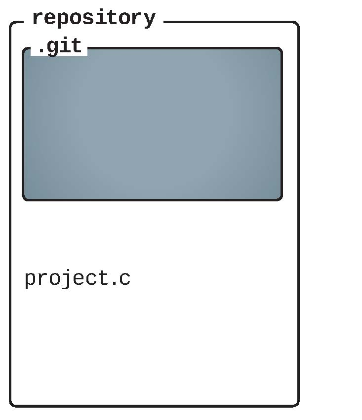

### How does it work?

Terminal:

```
$ git status
# On branch master
# Changes not staged for commit
#
# Untracked files:
#
#      project.c
#
```

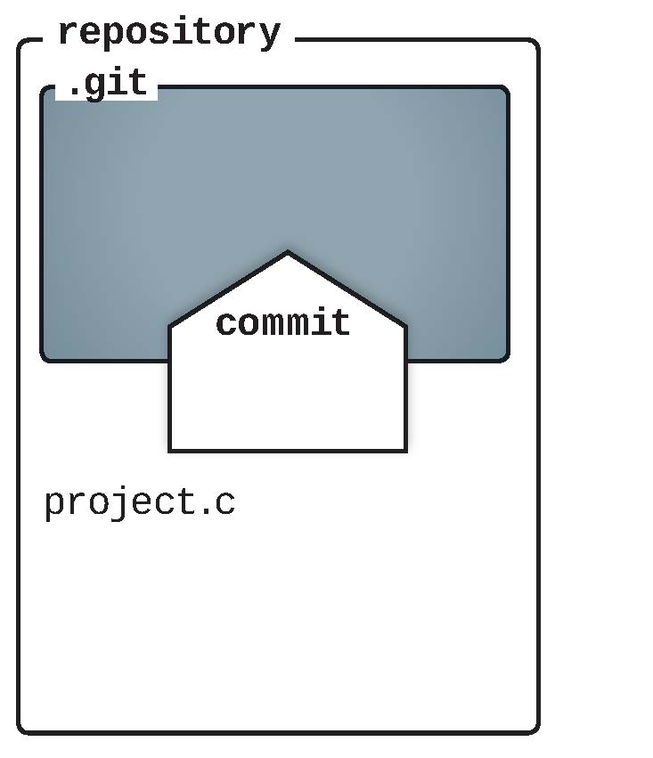

### How does it work?

Terminal:

```
$ git add project.c
```

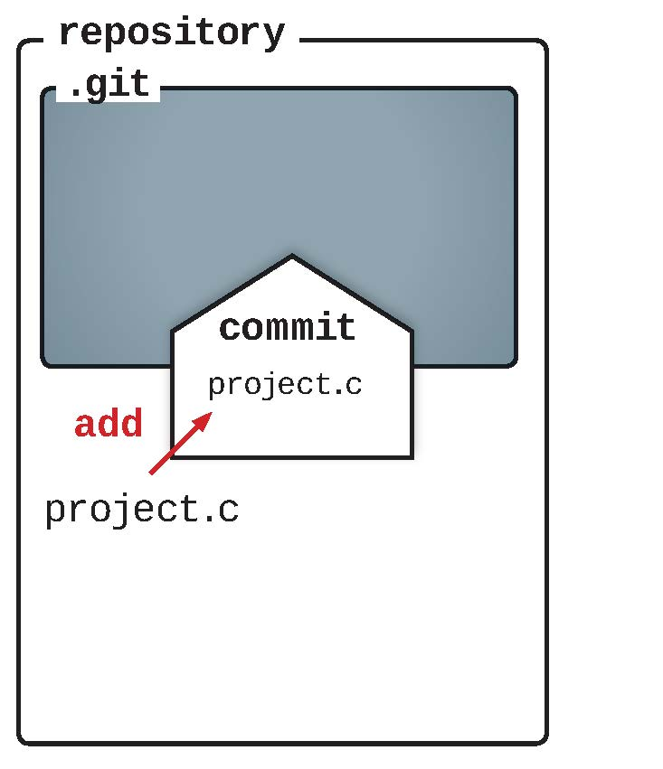

### How does it work?

Terminal:

```
$ git commit -m "initial project.c"
```

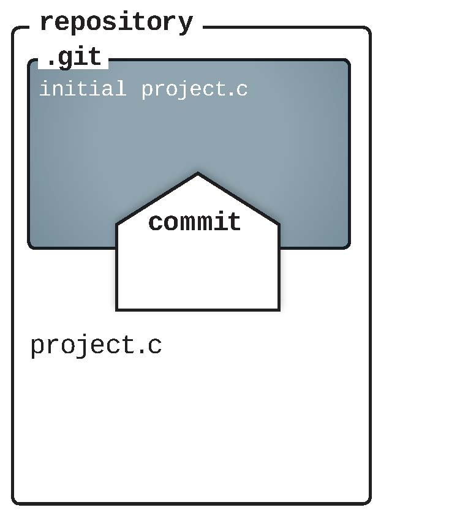

### How does it work?

Terminal:

```
$ git add project.c
```

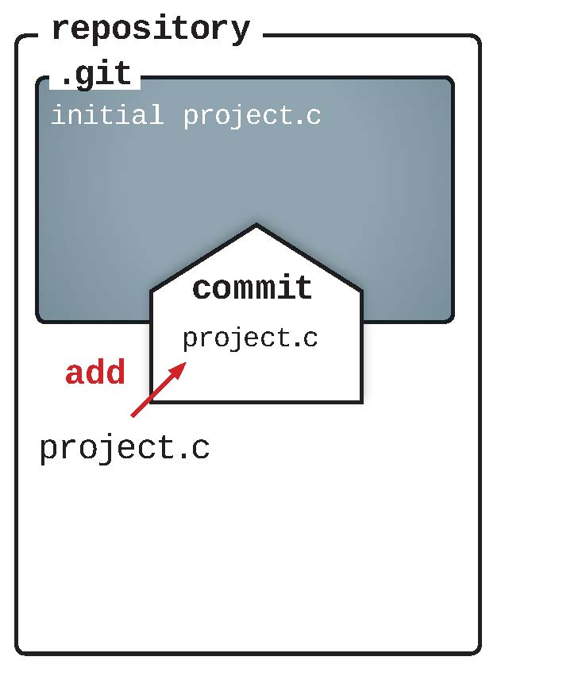

### How does it work?

Terminal:

```
$ git commit -m "fixed bug project.c"
```

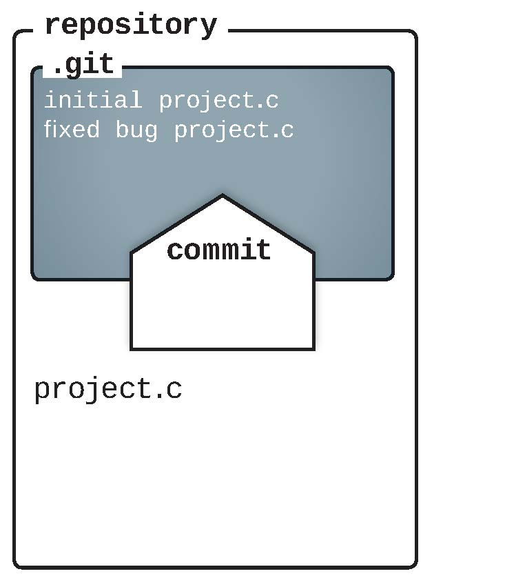

### How does it work?

Terminal:

```
$ git add project.c
```

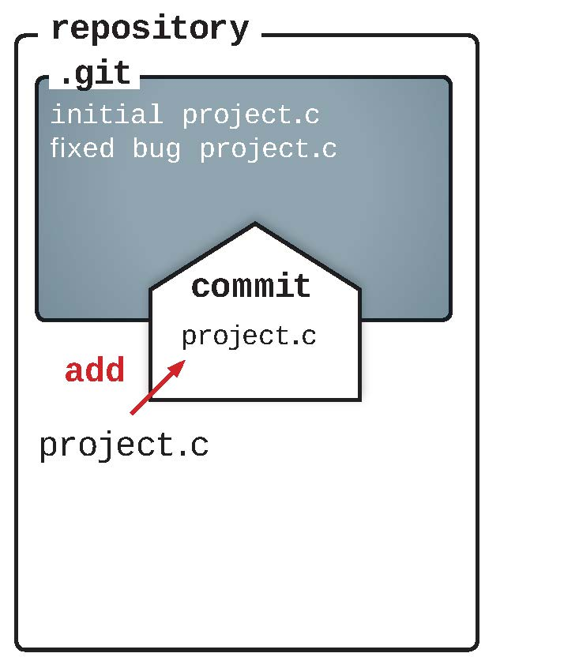

### How does it work?

Terminal:

[output not shown]

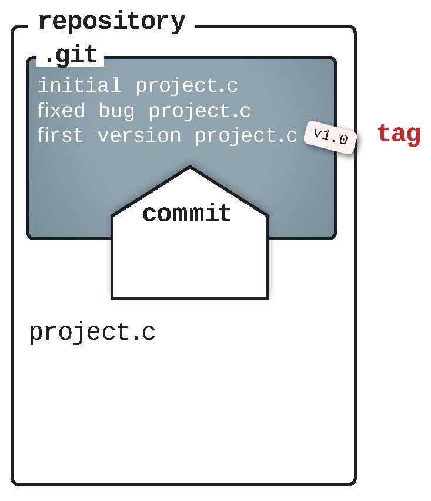

### How does it work?

[figure not shown]

### How does it work?

[figure not shown]

### How does it work?

[figure not shown]

### How does it work?

[figure not shown]

### How does it work?

[figure not shown]

### How does it work?

[figure not shown]

### How does it work?

[figure not shown]

### How does it work?

[figure not shown]

## Workflow

### Everyday git

1. work on files
2. commit to repository
   - adding files

   ```
   $ git add [file]
   ```

   - commit + message

   ```
   $ git commit -m "edit [file]"
   ```

### Once in a while git

1. tagging

   ```
   $ git tag [v*.*.*] -m "[newest version]"
   ```

2. time travelling

   ```
   $ git checkout v1.0
   $ git checkout master
   ```

3. branching

### graphical Clients

- Windows: [GitHub for Windows](http://windows.github.com/)
- Mac: [GitHub for Mac](http://mac.github.com/)
- Linux: [git-cola](http://git-cola.github.com/)
- all: [GitEye](http://www.giteyeapp.com/), [RStudio](http://www.rstudio.com) and other IDEs have plug-ins

many more: http://git-scm.com/downloads/guis

## Backing up & Syncing

### Working with remotes

- for syncing your computers
- or collaboration

### Working with remotes

[figure not shown]

### Working with remotes

[figure not shown]

### Working with remotes

[figure not shown]

### Working with remotes

[figure not shown]

### Working with remotes

[figure not shown]

### GitHub

- remote repositories
- **free** for open source projects (fully public!)
- private repositories (commercial)
- manage development (teams, tasks, milestones, wikis)

*Alternatives:*  
[Bitbucket](https://bitbucket.org/) (free private for small teams),  
[GitLab Cloud](https://about.gitlab.com/gitlab-com/) (unlimited free private),  
self-hosted git server, and many more

## Resources

### Resources

https://www.atlassian.com/git

http://git-scm.com/book/

http://git-scm.com/

https://training.github.com/kit/

## Exercises

## 1 | working locally

1. create a git repository locally
2. generate content
3. add and commit

## 2 | tagging

in same repository:

1. tag
2. edit content
3. add and commit
4. check history: `git log`
5. checkout tag
6. return to latest version

## 3 | GitHub

1. create a git repository on Github.
2. clone to local Computer:  
   `git clone https://github.com/user/repo`
3. generate content
4. add and commit
5. push (requires password)
6. edit online
7. pull

## 4 | Collaboration

1. clone shared project
2. create a file
3. add, commit, push
4. assign an issue (i.e. a task)
5. check your tasklist
6. pull repository
7. fullfill task
8. add, commit, push
9. check out progress on tasks

etc.: Milestones, Wiki

## Final Thoughts:

### Open source

- turn private repos public!
- choose a license: GPL or MIT for code, Creative Commons for text and data

Why?

- scientific work is of public concern
- enables re-use or inspiration
- transparency adds credibility
- scientific culture: acceptance of failure